# 478_Project_

### kNN classifer 10-fold validation with Cosine Distance

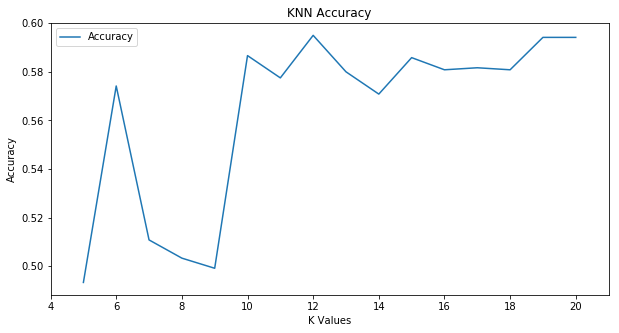

```
Max Accuracy score is  0.595 with K = 12
```

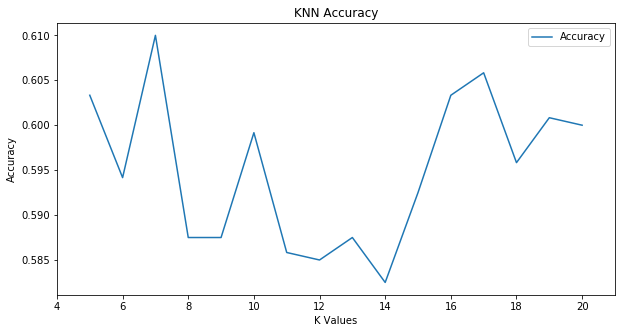

```
Max Accuracy score is  0.61 with K = 7
```

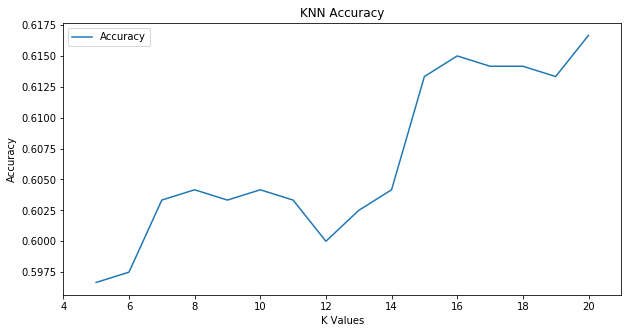

```
Max Accuracy score is  0.6166666666666667 with K = 20
```

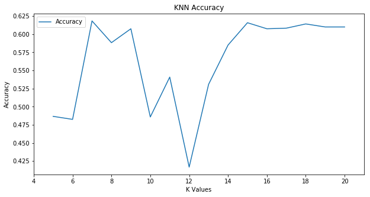

```
Max Accuracy score is  0.6183333333333333 with K = 7
```

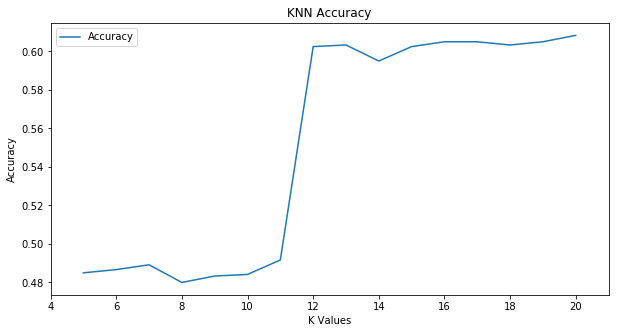

```
Max Accuracy score is  0.6083333333333333 with K = 20
```

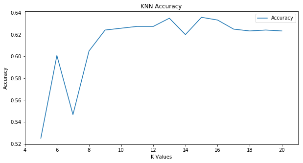

```
Max Accuracy score is  0.6358333333333334 with K = 15
```

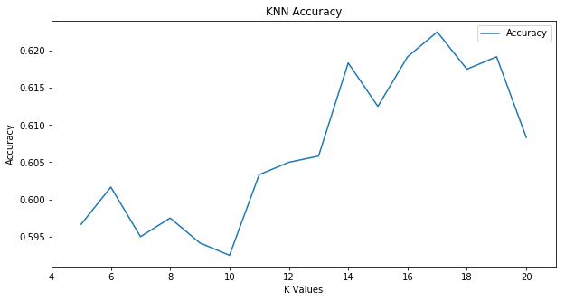

```
Max Accuracy score is  0.6225 with K = 17
```

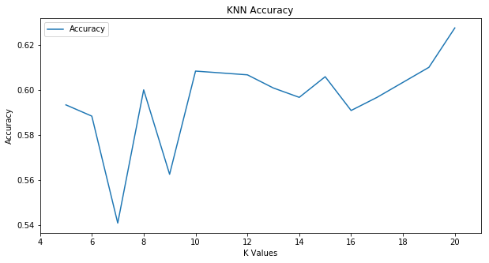

```
Max Accuracy score is  0.6275 with K = 20
```

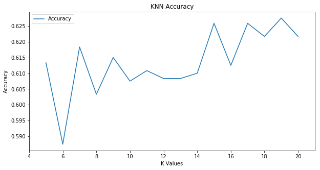

```
Max Accuracy score is  0.6275 with K = 19
```

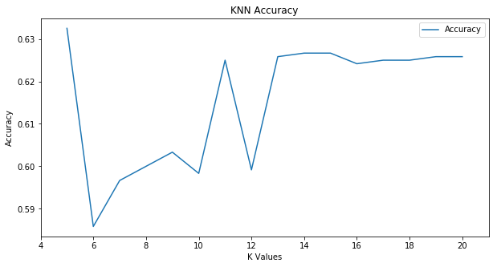

```
Max Accuracy score is  0.6325 with K = 5
** 10 Fold Cross Validation Result
Accuacy   K
----------------
0.636	15
0.632	5
0.627	19
0.627	20
0.623	17
0.618	7
0.617	20
0.610	7
0.608	20
0.595	12
```

```python
from sklearn.cross_validation import KFold

best_test_score_lst=[]
best_k_lst=[]

#set the number of fold for cross validation
n = 10
kf = KFold(len(tbl_dummies2), n_folds=n) #

K_min=5
K_max=20
for train,test in kf:
    #print(train)
    best_test_score, best_k,best_class = knn_accuracy(tbl_dummies2.iloc[train]
                                                      ,tbl_target2.iloc[train]
                                                      ,tbl_dummies2.iloc[test]
                                                      ,tbl_target2.iloc[test]
                                                      ,K_min,K_max,1)
    best_test_score_lst.append(best_test_score)
    best_k_lst.append(best_k)

best_test_score_lst=np.array(best_test_score_lst)
best_k_lst=np.array(best_k_lst)


idx = np.argsort(best_test_score_lst)[::-1]
idx = np.array(idx)

print("**",n,"Fold Cross Validation Result")
print("Accuacy   K")
print("----------------")
for i in idx:
    print("%0.3f\t%d"%(best_test_score_lst[i],best_k_lst[i]))
```

#### Based on the above KNN Cross-Validation result, the most frequent K with highest accuracy in each fold is 20. The average accuracy is about 61.7%

### kNN classifer 10-fold validation with Euclidean Distance

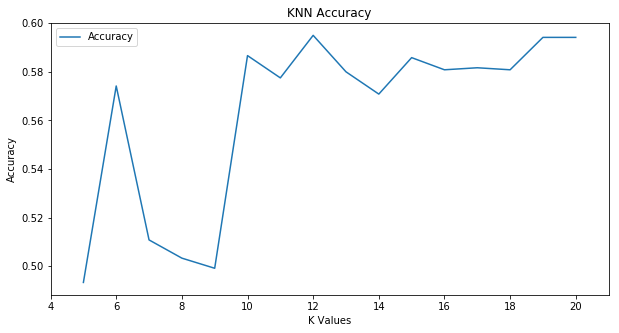

```
Max Accuracy score is  0.595 with K = 12
```

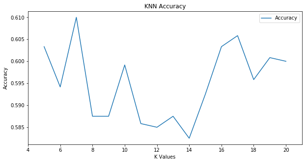

```
Max Accuracy score is  0.61 with K = 7
```

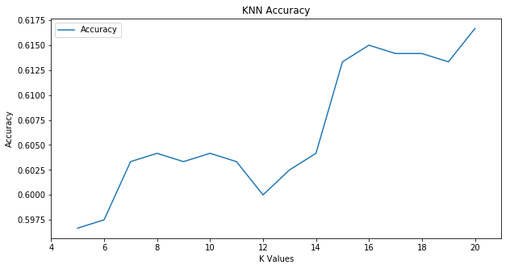

```
Max Accuracy score is  0.6166666666666667 with K = 20
```

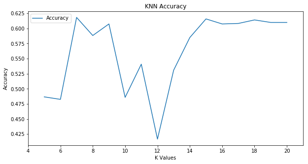

```
Max Accuracy score is  0.6183333333333333 with K = 7
```

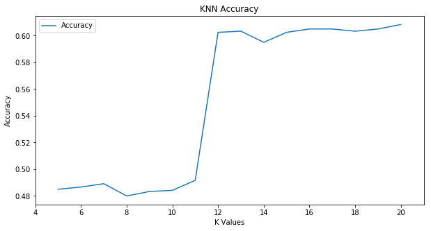

```
Max Accuracy score is  0.6083333333333333 with K = 20
```

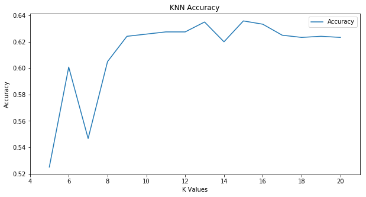

```
Max Accuracy score is  0.6358333333333334 with K = 15
```

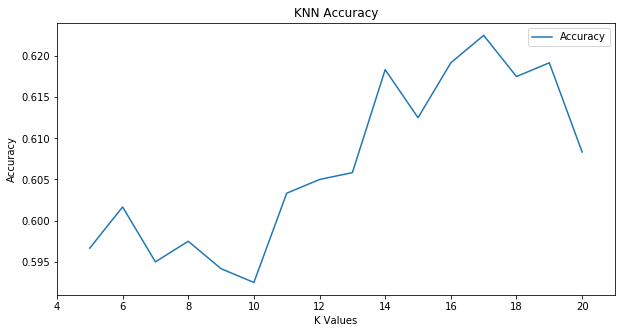

```
Max Accuracy score is  0.6225 with K = 17
```

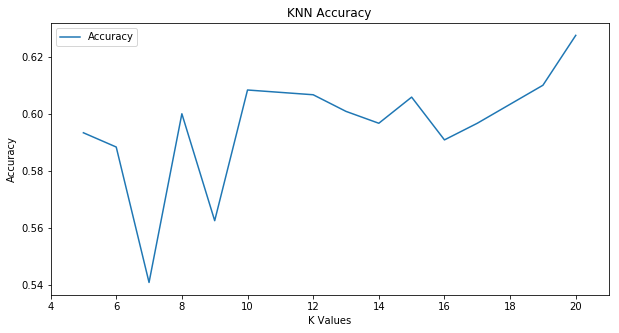

```
Max Accuracy score is  0.6275 with K = 20
```

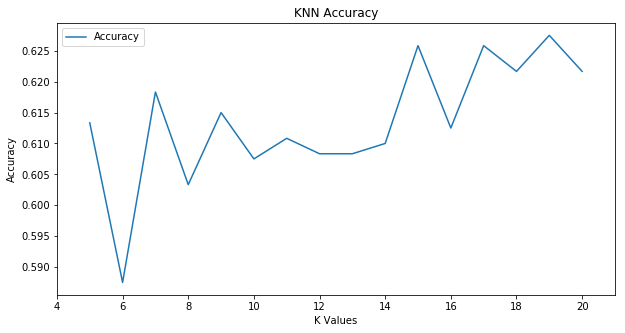

```
Max Accuracy score is  0.6275 with K = 19
```

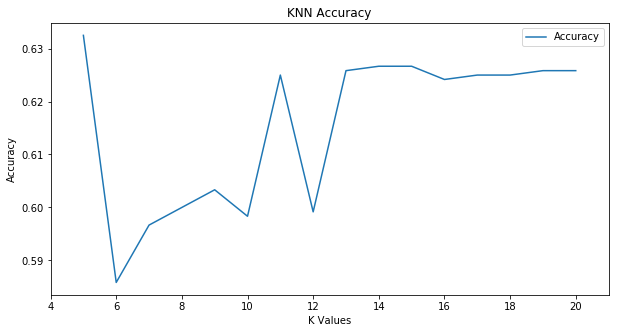

```
Max Accuracy score is  0.6325 with K = 5
** 10 Fold Cross Validation Result
Accuacy   K
----------------
0.636	15
0.632	5
0.627	19
0.627	20
0.623	17
0.618	7
0.617	20
0.610	7
0.608	20
0.595	12
```

```python
from sklearn.cross_validation import KFold

best_test_score_lst=[]
best_k_lst=[]

#set the number of fold for cross validation
n = 10
kf = KFold(len(tbl_dummies2), n_folds=n) #

K_min=5
K_max=20
for train,test in kf:
    #print(train)
    best_test_score, best_k,best_class = knn_accuracy(tbl_dummies2.iloc[train]
                                                      ,tbl_target2.iloc[train]
                                                      ,tbl_dummies2.iloc[test]
                                                      ,tbl_target2.iloc[test]
                                                      ,K_min,K_max,0)
    best_test_score_lst.append(best_test_score)
    best_k_lst.append(best_k)

best_test_score_lst=np.array(best_test_score_lst)
best_k_lst=np.array(best_k_lst)


idx = np.argsort(best_test_score_lst)[::-1]
idx = np.array(idx)

print("**",n,"Fold Cross Validation Result")
print("Accuacy   K")
print("----------------")
for i in idx:
    print("%0.3f\t%d"%(best_test_score_lst[i],best_k_lst[i]))
```

#### The above result shows that the result of using Euclidean and Cosine distance function are the SAME. The most frequent K with highest accuracy in each fold is 20. The average accuracy is about 61.7%. In this particular case, I would believethat those classified classes are far from those unclassied case. So that the result is so similar to each other.